# Topic 3 - Length-of-Stay Prediction in Hospitals

Participants: Tetiana Dzhenzherova, Sonja Hamm, Aissata Kane, Elene Kuprashvili, Xinran Zhang

- 1. Business Understanding and Objective
- 2. Data Understanding
  - 2.1 Loading Data and Imports
  - 2.2 Inspecting Data
  - 2.3 Definition of General Variables
- 3. Exploratory Data Analysis (EDA)
  - 3.1 Minimal Data Cleaning for Exploratory Data Analysis
  - 3.2 Univariate Analysis
  - 3.3 Bivariate Analysis
  - 3.4 Correlation Analysis
- 4. Data Cleaning & Preprocessing
  - 4.1 Split Data into Test and Validation Sets
  - 4.2 Target Data Preparation
  - 4.3 Features Preprocessing
- 5. Model Selection
  - 5.1 Models Definition
  - 5.2 Model Selection
  - 5.3 Training and Evaluating Best Model on Full Data
- 6. Feature Importance & Explainability
- 7. Conclusion & Recommendations

## 1. Business Understanding and Objective

**Problem statement**

Hospitals often face challenges in efficiently managing resources due to the varying length of stay (LOS) among patients.

This project aims to estimate the expected Length of Stay for new patients based on historical data of previous patients with known varying length of stay, using key hospital-related and patient-related indicators.

This Project will use different machine learning models to predict LOS. All of them will be evaluated, to define the best model for this project.

**Business/clinical context**

Accurant predictions of length of stay can help hospitals with:

• Optimoptimization of treatment planning for patients, who have high risk of prolonged stays

• Minimization of the varying length of stay in the hospital and improve efficiency in operational context

• logistical management, which includes room and bed allocation

**About dataset**

• Data that is used is original dataset from Topic3_healthcare_analytics_dataset.csv. It contains features related to patient, hospital and Length of stay for some patients on an individual case basis.

• The target variable is 'Stay', which categorizes stay duration in 11 categories, which differ by the length of stay in days (e.g. 0-10, 11-20, ..., More than 100 days).

• Each row in the raw data set represents a patient admission and therefore a unique case.

• Main features in the dataset include Age, Type of Amission, Severity of Illness, Department, Ward Type, Ward facility code, Bed Grade, Available Extra Rooms in Hospital, Visitors with Patient, Admission Deposit, Hospital Code, and Hospital Type Code.

**Main Objective**

Our main objective is to train and evaluate a machine learning model that accurately predicts the patients' length of stays in the hospital, based on available data. This will help hospital management allocate resources, plan capacity, and improve patient health care outcomes.

## 2. Data Understanding

### 2.1 Loading Data and Imports

```python
# CORE LIBRARIES
import numpy as np
import pandas as pd

# DATA VISUALIZATION
import matplotlib.pyplot as plt
import seaborn as sns

# DATA PREPROCESSING
from sklearn.impute import SimpleImputer
from sklearn.preprocessing import (
    StandardScaler,
    OneHotEncoder,
    OrdinalEncoder
)
from category_encoders import TargetEncoder
from sklearn.compose import ColumnTransformer
from sklearn.pipeline import Pipeline

# MACHINE LEARNING MODELS
from sklearn.tree import DecisionTreeClassifier
from sklearn.ensemble import RandomForestClassifier
from ogboost import GradientBoostingOrdinal  # ordinal classification model
from sklearn.linear_model import LogisticRegression
from lightgbm import LGBMClassifier
from sklearn.model_selection import RandomizedSearchCV

#SPLITTING DATA SETS INTO TRAINING AND VALIDATION SETS
from sklearn.model_selection import train_test_split

# MODEL EVALUATION METRICS
from sklearn.metrics import (
    accuracy_score,
    cohen_kappa_score,
    mean_absolute_error,
    make_scorer
)
```

```python
df = pd.read_csv("Topic3_healthcare_analytics_dataset.csv")
df.head()
```

|  | case_id | Hospital_code | Hospital_type_code | City_Code_Hospital | Hospital_region_code | Available Extra Rooms in Hospital | Department | Ward_Type | Ward_Facility_Code | Bed Grade | patientid | City_Code_Patient | Type of Admission | Severity of Illness | Visitors with Patient | Age | Admission_Deposit | Stay |
| --- | --- | --- | --- | --- | --- | --- | --- | --- | --- | --- | --- | --- | --- | --- | --- | --- | --- | --- |
| 0 | 1 | 8 | c | 3 | Z | 3 | radiotherapy | R | F | 2.0 | 31397 | 7.0 | Emergency | Extreme | 2 | 51-60 | 4911.0 | 0-10 |
| 1 | 2 | 2 | c | 5 | Z | 2 | radiotherapy | S | F | 2.0 | 31397 | 7.0 | Trauma | Extreme | 2 | 51-60 | 5954.0 | 41-50 |
| 2 | 3 | 10 | e | 1 | X | 2 | anesthesia | S | E | 2.0 | 31397 | 7.0 | Trauma | Extreme | 2 | 51-60 | 4745.0 | 31-40 |
| 3 | 4 | 26 | b | 2 | Y | 2 | radiotherapy | R | D | 2.0 | 31397 | 7.0 | Trauma | Extreme | 2 | 51-60 | 7272.0 | 41-50 |
| 4 | 5 | 26 | b | 2 | Y | 2 | radiotherapy | S | D | 2.0 | 31397 | 7.0 | Trauma | Extreme | 2 | 51-60 | 5558.0 | 41-50 |

```python
# Suppress warnings
import warnings
warnings.filterwarnings('ignore')
```

### 2.2 Inspecting Data

We will first inspect the raw data.

```python
df.shape
```

```
(455495, 18)
```

Our dataframe has 455495 observations, and 18 variables.

```python
print("Features: ", [col for col in df.columns if col != 'Stay'])
```

```
Features:  ['case_id', 'Hospital_code', 'Hospital_type_code', 'City_Code_Hospital', 'Hospital_region_code', 'Available Extra Rooms in Hospital', 'Department', 'Ward_Type', 'Ward_Facility_Code', 'Bed Grade', 'patientid', 'City_Code_Patient', 'Type of Admission', 'Severity of Illness', 'Visitors with …
```

```python
# Checking for duplicate rows
df.duplicated().sum()
```

```
np.int64(0)
```

There are no duplicate rows in our data set.

```python
df.dtypes
```

```
case_id                                int64
Hospital_code                          int64
Hospital_type_code                    object
City_Code_Hospital                     int64
Hospital_region_code                  object
Available Extra Rooms in Hospital      int64
Department                            object
Ward_Type                             object
Ward_Facility_Code                    object
Bed Grade                            float64
patientid                              int64
City_Code_Patient                    float64
Type of Admission                     object
Severity of Illness                   object
Visitors with Patient                  int64
Age                                   object
Admission_Deposit                    float64
Stay                                  object
dtype: object
```

This dataframe is mainly made of categorical features, except Admission Deposit, available extra rooms and Visitors with Patient. These numerical features might need to be normilized during data preprocessing to not skew the ML models results.

*Note: Many of the categorical features have a numerical data type, which will need to be changed to a categorical data type before usage in ML models.*

```python
df.describe()
```

|  | case_id | Hospital_code | City_Code_Hospital | Available Extra Rooms in Hospital | Bed Grade | patientid | City_Code_Patient | Visitors with Patient | Admission_Deposit |
| --- | --- | --- | --- | --- | --- | --- | --- | --- | --- |
| count | 455495.00000 | 455495.000000 | 455495.000000 | 455495.000000 | 455347.000000 | 455495.000000 | 448806.000000 | 455495.000000 | 455495.000000 |
| mean | 227748.00000 | 18.326335 | 4.767798 | 3.196140 | 2.628420 | 65786.793563 | 7.249495 | 3.284229 | 4877.434022 |
| std | 131490.22477 | 8.634036 | 3.102450 | 1.166994 | 0.871997 | 37968.830850 | 4.758941 | 1.768044 | 1084.982089 |
| min | 1.00000 | 1.000000 | 1.000000 | 0.000000 | 1.000000 | 1.000000 | 1.000000 | 0.000000 | 1800.000000 |
| 25% | 113874.50000 | 11.000000 | 2.000000 | 2.000000 | 2.000000 | 32874.000000 | 4.000000 | 2.000000 | 4184.000000 |
| 50% | 227748.00000 | 19.000000 | 5.000000 | 3.000000 | 3.000000 | 65735.000000 | 8.000000 | 3.000000 | 4738.000000 |
| 75% | 341621.50000 | 26.000000 | 7.000000 | 4.000000 | 3.000000 | 98576.500000 | 8.000000 | 4.000000 | 5405.000000 |
| max | 455495.00000 | 32.000000 | 13.000000 | 24.000000 | 4.000000 | 131624.000000 | 38.000000 | 32.000000 | 11920.000000 |

```python
df.info()
```

```
<class 'pandas.core.frame.DataFrame'>
RangeIndex: 455495 entries, 0 to 455494
Data columns (total 18 columns):
 #   Column                             Non-Null Count   Dtype
---  ------                             --------------   -----
 0   case_id                            455495 non-null  int64
 1   Hospital_code                      455495 non-null  int64
 2   Hospital_type_code                 455495 non-null  object
 3   City_Code_Hospital                 455495 non-null  int64
 4   Hospital_region_code               455495 non-null  object
 5   Available Extra Rooms in Hospital  455495 non-null  int64
 6   Department                         455495 non-null  object
 7   Ward_Type                          455495 non-null  object
 8   Ward_Facility_Code                 455495 non-null  object
 9   Bed Grade                          455347 non-null  float64
 10  patientid                          455495 non-null  int64
 11  City_Code_Patient                  448806 non-null  float64
 12  Type of Admission                  455495 non-null  object
 13  Severity of Illness                455495 non-null  object
 14  Visitors with Patient              455495 non-null  int64
 15  Age                                455495 non-null  object
 16  Admission_Deposit                  455495 non-null  float64
 17  Stay                               318438 non-null  object
dtypes: float64(3), int64(6), object(9)
memory usage: 62.6+ MB
```

### 2.3 Definition of General Variables

In this section we define general variables which will be used throughout this project:

- Numerical Columns/Features
- Categorical Columns/Features
- Ordinal Categorical Columns/Features
- Non-Ordinal Categorical Columns/Features
- Target VS Features

```python
numeric_columns = ['Available Extra Rooms in Hospital', 'Visitors with Patient',
                   'Admission_Deposit']

categorical_columns = [
    'Hospital_code', 'Hospital_type_code', 'City_Code_Hospital',
    'Hospital_region_code', 'Department', 'Ward_Type',
    'Ward_Facility_Code', 'Bed Grade', 'City_Code_Patient',
    'Type of Admission', 'Severity of Illness', 'Age', 'Stay'
]

ordinal_columns = ['Bed Grade', 'Severity of Illness', 'Age', 'Stay']
nominal_columns = list(set(categorical_columns) - set(ordinal_columns))
target = 'Stay'
features = [col for col in df.columns if col != target]
```

## 3. Exploratory Data Analysis (EDA)

We now perform exploratory data analysis in order to explore distributions of the varaiables, detect patterns and relationships between the variables.

```python
df_eda = df.copy()
```

### 3.1 Minimal Data Cleaning for Exploratory Data Analysis

In order to make the data ready for analysis, we will temporarily handle:

- Missing data
- Categorical variables/features
- Inconsistent Data types
- Detection of outliers

#### Fixing Data Types

```python
# Set numeric columns' data type as 'int'
df_eda[numeric_columns] = df_eda[numeric_columns].astype('int')

# Set categorical columns' data type as 'object'
df_eda[categorical_columns] = df_eda[categorical_columns].astype('object')

df_eda.dtypes
```

```
case_id                               int64
Hospital_code                        object
Hospital_type_code                   object
City_Code_Hospital                   object
Hospital_region_code                 object
Available Extra Rooms in Hospital     int64
Department                           object
Ward_Type                            object
Ward_Facility_Code                   object
Bed Grade                            object
patientid                             int64
City_Code_Patient                    object
Type of Admission                    object
Severity of Illness                  object
Visitors with Patient                 int64
Age                                  object
Admission_Deposit                     int64
Stay                                 object
dtype: object
```

#### Handling Missing values

```python
df_eda.isna().sum()
```

```
case_id                                   0
Hospital_code                             0
Hospital_type_code                        0
City_Code_Hospital                        0
Hospital_region_code                      0
Available Extra Rooms in Hospital         0
Department                                0
Ward_Type                                 0
Ward_Facility_Code                        0
Bed Grade                               148
patientid                                 0
City_Code_Patient                      6689
Type of Admission                         0
Severity of Illness                       0
Visitors with Patient                     0
Age                                       0
Admission_Deposit                         0
Stay                                 137057
dtype: int64
```

Only Bed Grade and City_Code_Patient contain missing values, as well as the target Stay.

All three features are categorical in nature:

- 'Bed Grade' is an ordinal variable representing the level or quality of hospital beds (1–4). Missing values will be filled with **the mode**.
- 'City_Code_Patient' is a nominal variable representing patient city identifiers. Missing values will be filled with **the mode** to maintain the categorical balance of the dataset.
- Stay represents the length of stay in 10 day intervals (1-10, 11-20,...,More than a 100 days). We will delete rows with missing Stay value when necessary to compute correlation with features and in the preprocessing steps before training our ML models.

```python
# Imputing mode to missing values in Bed Grade and City Code Patient
df_eda['Bed Grade'] = df_eda['Bed Grade'].fillna(df_eda['Bed Grade'].mode()[0])
df_eda['City_Code_Patient'] = df_eda['City_Code_Patient'].fillna(df_eda['City_Code_Patient'].mode()[0])

# Checking if there are any missing values left
df_eda[['Bed Grade', 'City_Code_Patient']].isna().sum()
```

```
Bed Grade            0
City_Code_Patient    0
dtype: int64
```

#### Identifying and capping outliers in numerical variables

Before proceeding to correlation or modeling, it is important to identify potential outliers that could distort statistical relationships. We will focus on three numerical columns:

- “Available Extra Rooms in Hospital”
- “Visitors with Patient”
- “Admission_Deposit”

Box plots will be used for visual inspection, and the interquartile range (IQR) method will be used to calculate statistical limits for each variable. These limits will help identify values that are extremely high or low compared to the majority.

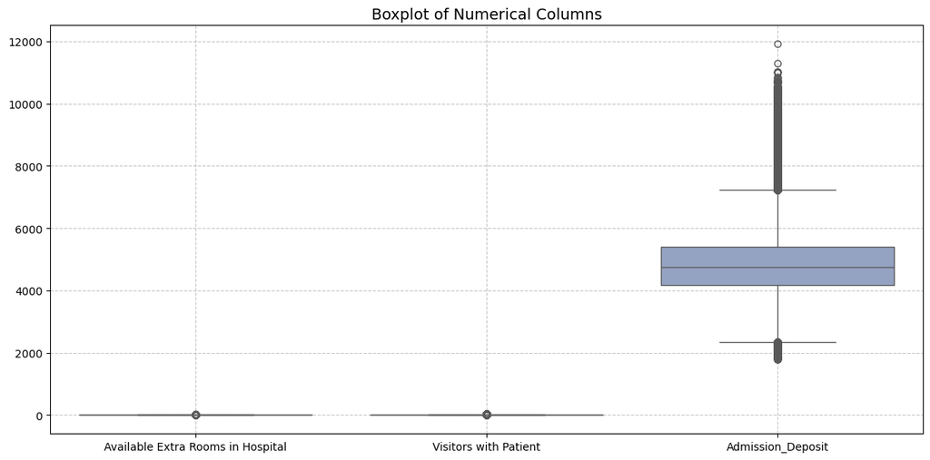

```
Available Extra Rooms in Hospital:
 - Lower bound: 0
 - Upper bound: 7.0
 - Number of outliers: 1936

Visitors with Patient:
 - Lower bound: 0
 - Upper bound: 7.0
 - Number of outliers: 13884

Admission_Deposit:
 - Lower bound: 2352.5
 - Upper bound: 7236.5
 - Number of outliers: 17558
```

```python
plt.figure(figsize=(12,6))
sns.boxplot(data=df_eda[numeric_columns], palette="Set2")
plt.title("Boxplot of Numerical Columns", fontsize=14)
plt.grid(True, linestyle='--', alpha=0.7)
plt.tight_layout()
plt.show()

# Here we calculate IQR boundaries for each numeric column
for col in numeric_columns:
    Q1 = df_eda[col].quantile(0.25)
    Q3 = df_eda[col].quantile(0.75)
    IQR = Q3 - Q1
    lower = Q1 - 1.5 * IQR
    upper = Q3 + 1.5 * IQR

    if lower < 0:
        lower = 0

    outliers = df_eda[(df[col] < lower) | (df_eda[col] > upper)][col].count()
    print(f"{col}:")
    print(f" - Lower bound: {lower}")
    print(f" - Upper bound: {upper}")
    print(f" - Number of outliers: {outliers}\n")
```

**Available Extra Rooms in Hospital:**

Most hospitals have up to 7 extra rooms available. A small number of hospitals report higher values, which may indicate larger facilities or data anomalies.

**Visitors with Patient:**

Most patients are accompanied by fewer than 7 visitors. However, a notable number of records exceed this threshold, possibly due to recording errors or exceptional cases.

**Admission_Deposit:**

The majority of admission deposits fall within this range between 2,352.5 and 7,236.5. Values above 7,236 may represent premium treatments or incorrect entries.

All three numerical variables: Available Extra Rooms in Hospital, Visitors with Patient, and Admission_Deposit, contain outliers that extend beyond the normal range defined by the IQR method.

However, these extreme values do not necessarily represent data entry errors. In a hospital context, unusually high numbers of visitors, available rooms, or deposit amounts can occur naturally due to differences in hospital size, service quality, or patient type. For this reason, we have decided not to remove or cap outliers.

#### Encoding Categorical Variables

We will also temporarily encoded all categrorical data in order to perform our initial exploratory data analysis.

```python
# Define explicit orders for ordinal features
ordinal_orders = {
    'Bed Grade': [1, 2, 3, 4],  # example order
    'Severity of Illness': ['Minor', 'Moderate', 'Severe'],
    'Age': ['0-10', '11-20', '21-30', '31-40', '41-50', '51-60', '61-70', '71-80', '81-90', '91-100', 'More than 100'],
    'Stay': ['0-10', '11-20', '21-30', '31-40', '41-50', '51-60', '61-70', '71-80', '81-90', '91-100', 'More than 100 Days']
}

# Temporary encoding for EDA
df_encoded = df_eda.copy()

# Encode ordinal features
for col in ordinal_columns:
    if col in ordinal_orders:
        df_encoded[col] = pd.Categorical(df_encoded[col], categories=ordinal_orders[col], ordered=True).codes
    else:
        # fallback: convert to category codes
        df_encoded[col] = df_encoded[col].astype('category').cat.codes

# Encode nominal features
for col in nominal_columns:
    df_encoded[col] = df_encoded[col].astype('category').cat.codes

# Check if there are any missing values left:
df_encoded.isna().sum().sum()

print(df_encoded.head())
```

```
   case_id  Hospital_code  Hospital_type_code  City_Code_Hospital  \
0        1              7                   2                   2
1        2              1                   2                   4
2        3              9                   4                   0
3        4             25                   1                   1
4        5             25                   1                   1

   Hospital_region_code  Available Extra Rooms in Hospital  Department  \
0                     2                                  3           3
1                     2                                  2           3
2                     0                                  2           1
3                     1                                  2           3
4                     1                                  2           3

   Ward_Type  Ward_Facility_Code  Bed Grade  patientid  City_Code_Patient  \
```

[output cut: 19 more lines]

### 3.2 Univariate Analysis

We will now perform univariate analysis to analyse the distribution of each variable.

#### Target variable analysis - Hospital Stay Duration Distribution

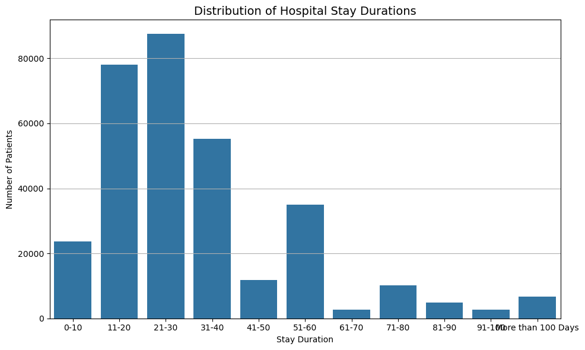

```python
stay_order = ordinal_orders['Stay']

df_encoded['Stay_label'] = df_encoded['Stay'].map({i: label for i, label in enumerate(stay_order)})

plt.figure(figsize=(10, 6))
sns.countplot(x='Stay_label', data=df_encoded, order=stay_order)
plt.title("Distribution of Hospital Stay Durations", fontsize=14)
plt.xlabel("Stay Duration")
plt.ylabel("Number of Patients")
plt.xticks(rotation=0)
plt.grid(axis='y')
plt.tight_layout()
plt.show()
```

The distribuation of the variable Stay is right-skewed, with most patients staying between 11 to 30 days, indicating that a shorter hospital stay duration is more common. The tail toward higher durations, reflects a small number of outlier cases with extended stays.

#### Categorical Variables Analysis

For the analysis of all categorial variables we will do the following:

- Map encoded numeric values back to text labels
- Apply mapping to create human-readable labels
- Plot distribution

##### Type of Admission

```python
df_encoded['Type of Admission'].unique()
```

```
array([0, 1, 2], dtype=int8)
```

```python
df_encoded['Type of Admission'].value_counts().sort_index()
```

```
Type of Admission
0    168363
1    217672
2     69460
Name: count, dtype: int64
```

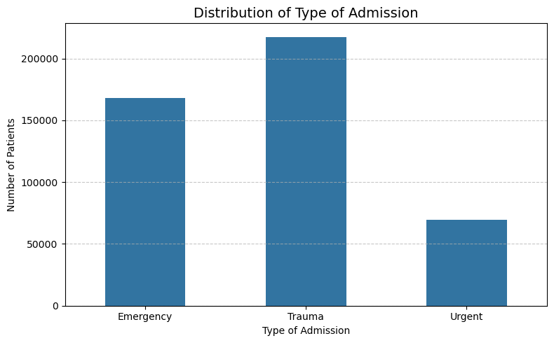

```python
admission_map = {
     0: 'Emergency',
     1: 'Trauma',
     2: 'Urgent'
}

df_encoded['Admission_label'] = df_encoded['Type of Admission'].map(admission_map)

plt.figure(figsize=(8, 5))
admission_order = ['Emergency', 'Trauma', 'Urgent']

sns.countplot(
    x='Admission_label',
    data=df_encoded,
    width=0.5,
    order=admission_order
)

plt.title("Distribution of Type of Admission", fontsize=14)
plt.xlabel("Type of Admission")
plt.ylabel("Number of Patients")
plt.grid(axis='y', linestyle='--', alpha=0.7)
plt.tight_layout()
plt.show()
```

##### Severity of Illness Distribution

```python
df_encoded['Severity of Illness'].unique()
```

```
array([-1,  1,  0], dtype=int8)
```

```python
df_encoded['Severity of Illness'].value_counts().sort_index()
```

```
Severity of Illness
-1     81195
 0    122735
 1    251565
Name: count, dtype: int64
```

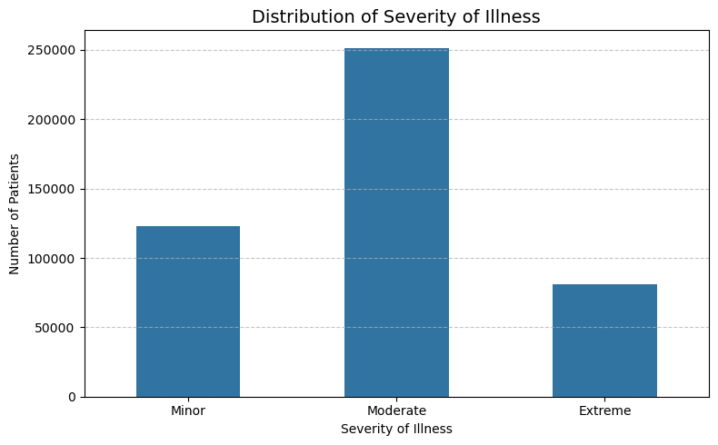

```python
severity_map = {-1: 'Extreme', 0: 'Minor', 1: 'Moderate'}
df_encoded['Severity_label'] = df_encoded['Severity of Illness'].map(severity_map)

plt.figure(figsize=(8, 5))
severity_order = ['Minor', 'Moderate', 'Extreme']

sns.countplot(
    x='Severity_label',
    data=df_encoded,
    width=0.5,
    order=severity_order
)

plt.title("Distribution of Severity of Illness", fontsize=14)
plt.xlabel("Severity of Illness")
plt.ylabel("Number of Patients")
plt.grid(axis='y', linestyle='--', alpha=0.7)
plt.tight_layout()
plt.show()
```

The distribution of Severity of Illness appears balanced and realistic.

Most patients are categorized as Moderate, while Minor and Extreme severities occur less frequently but still represent substantial portions of the dataset. We can suggest that there are a reasonable variety of cases and indicates that the variable is well distributed across categories.

##### Department

```python
df_encoded['Department'].unique()
```

```
array([3, 1, 2, 0, 4], dtype=int8)
```

```python
df_encoded['Department'].value_counts().sort_index()
```

```
Department
0     13751
1     42358
2    356688
3     41033
4      1665
Name: count, dtype: int64
```

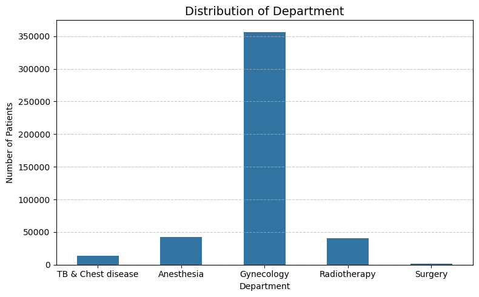

```python
department_map = {
     0: 'TB & Chest disease',
     1: 'Anesthesia',
     2: 'Gynecology',
     3: 'Radiotherapy',
     4: 'Surgery'
}

df_encoded['Department_label'] = df_encoded['Department'].map(department_map)

plt.figure(figsize=(8, 5))
department_order = ['TB & Chest disease', 'Anesthesia', 'Gynecology', 'Radiotherapy', 'Surgery']

sns.countplot(
    x='Department_label',
    data=df_encoded,
    width=0.5,
    order=department_order
)

plt.title("Distribution of Department", fontsize=14)
plt.xlabel("Department")
plt.ylabel("Number of Patients")
plt.grid(axis='y', linestyle='--', alpha=0.7)
plt.tight_layout()
plt.show()
```

Most records belong to the Gynecology Department, while other departments such as Anesthesia, Radiotherapy, and TB & Chest Disease have significantly fewer cases. Surgery accounts for only a minimal share of the dataset. Based on this result we can indicate that the data is heavily dominated by gynecology-related records, possibly reflecting hospitals specialisations.

##### Ward_Type

```python
df_encoded['Ward_Type'].unique()
```

```
array([2, 3, 1, 0, 4, 5], dtype=int8)
```

```python
df_encoded['Ward_Type'].value_counts().sort_index()
```

```
Ward_Type
0      7199
1    152046
2    182939
3    111166
4      2133
5        12
Name: count, dtype: int64
```

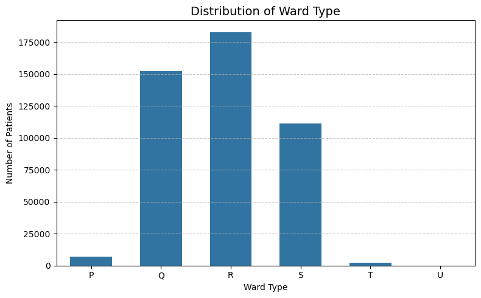

```python
ward_type_map = {
     0: 'P',
     1: 'Q',
     2: 'R',
     3: 'S',
     4: 'T',
     5: 'U'
}

df_encoded['Ward_Type_label'] = df_encoded['Ward_Type'].map(ward_type_map)

plt.figure(figsize=(8, 5))
ward_order = ['P','Q', 'R', 'S', 'T', 'U']

sns.countplot(
    x='Ward_Type_label',
    data=df_encoded,
    width=0.6,
    order=ward_order
)

plt.title("Distribution of Ward Type", fontsize=14)
plt.xlabel("Ward Type")
plt.ylabel("Number of Patients")
plt.grid(axis='y', linestyle='--', alpha=0.7)
plt.tight_layout()
plt.show()
```

The dataset shows a strong variation in the number of patients across different ward types. Most records belong to Ward Type R, followed by Q and S, while P, T, and U have very few patients. We can suggests that most patients were assigned to standard or frequently used wards, while some ward categories were rarely used, possibly indicating specialized or limited-capacity units.

##### Ward_Facility_Code

```python
df_encoded['Ward_Facility_Code'].unique()
```

```
array([5, 4, 3, 1, 0, 2], dtype=int8)
```

```python
df_encoded['Ward_Facility_Code'].value_counts().sort_index()
```

```
Ward_Facility_Code
0     40260
1     50116
2     50279
3     74312
4     79058
5    161470
Name: count, dtype: int64
```

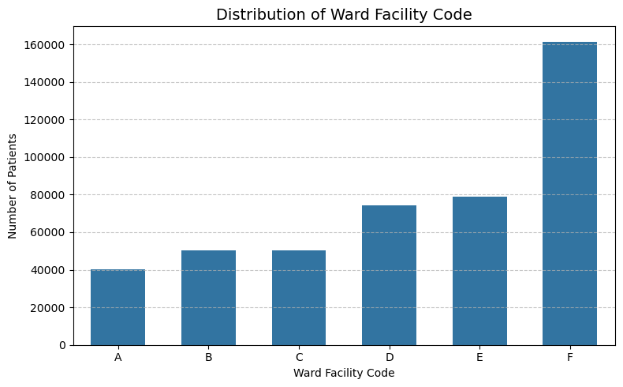

```python
ward_facility_map = {
     0: 'A',
     1: 'B',
     2: 'C',
     3: 'D',
     4: 'E',
     5: 'F'
}

df_encoded['Ward_Facility_label'] = df_encoded['Ward_Facility_Code'].map(ward_facility_map)

plt.figure(figsize=(8, 5))
facility_order = ['A', 'B', 'C', 'D', 'E', 'F']

sns.countplot(
    x='Ward_Facility_label',
    data=df_encoded,
    width=0.6,
    order=facility_order
)

plt.title("Distribution of Ward Facility Code", fontsize=14)
plt.xlabel("Ward Facility Code")
plt.ylabel("Number of Patients")
plt.grid(axis='y', linestyle='--', alpha=0.7)
plt.tight_layout()
plt.show()
```

The chart shows that Ward Facility Code F has the highest number of patients, significantly more than any other facility code. Codes A to E have relatively balanced and moderate distributions, with a gradual increase from A to E. This result suggests that facility F is the most frequently used or possibly the largest ward facility, while the others handle fewer admissions.

##### Hospital_type_code

```python
df_encoded['Hospital_type_code'].unique()
```

```
array([2, 4, 1, 0, 5, 3, 6], dtype=int8)
```

```python
df_encoded['Hospital_type_code'].value_counts().sort_index()
```

```
Hospital_type_code
0    204730
1     98884
2     66147
3     29048
4     35428
5     15252
6      6006
Name: count, dtype: int64
```

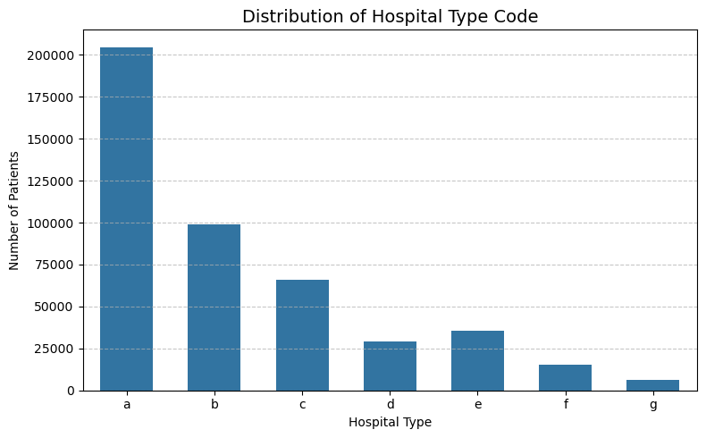

```python
hospital_type_map = {
     0: 'a',
     1: 'b',
     2: 'c',
     3: 'd',
     4: 'e',
     5: 'f',
     6: 'g'
}

df_encoded['Hospital_type_label'] = df_encoded['Hospital_type_code'].map(hospital_type_map)
plt.figure(figsize=(8, 5))
hospital_order = ['a', 'b', 'c', 'd', 'e', 'f', 'g']

sns.countplot(
    x='Hospital_type_label',
    data=df_encoded,
    width=0.6,
    order=hospital_order
)

plt.title("Distribution of Hospital Type Code", fontsize=14)
plt.xlabel("Hospital Type")
plt.ylabel("Number of Patients")
plt.grid(axis='y', linestyle='--', alpha=0.7)
plt.tight_layout()
plt.show()
```

The distribution shows that most records belong to hospital type a, followed by b and c, while hospitals labeled f and g have the smallest number of patients.

##### Hospital_region_code

```python
df_encoded['Hospital_region_code'].unique()
```

```
array([2, 0, 1], dtype=int8)
```

```python
df_encoded['Hospital_region_code'].value_counts().sort_index()
```

```
Hospital_region_code
0    190849
1    174707
2     89939
Name: count, dtype: int64
```

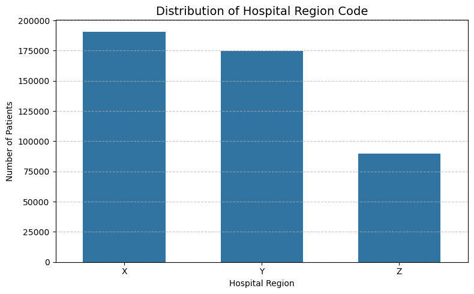

```python
region_map = {
     0: 'X',
     1: 'Y',
     2: 'Z'
}

df_encoded['Hospital_region_label'] = df_encoded['Hospital_region_code'].map(region_map)

plt.figure(figsize=(8, 5))
region_order = ['X', 'Y', 'Z']

sns.countplot(
    x='Hospital_region_label',
    data=df_encoded,
    width=0.6,
    order=region_order,
)

plt.title("Distribution of Hospital Region Code", fontsize=14)
plt.xlabel("Hospital Region")
plt.ylabel("Number of Patients")
plt.grid(axis='y', linestyle='--', alpha=0.7)
plt.tight_layout()
plt.show()
```

##### Bed Grade

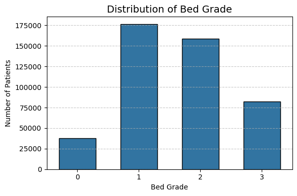

```python
plt.figure(figsize=(6,4))

sns.countplot(
    x='Bed Grade',
    data=df_encoded,
    edgecolor='black',
    width=0.6
)

plt.title("Distribution of Bed Grade", fontsize=14)
plt.xlabel("Bed Grade")
plt.ylabel("Number of Patients")
plt.grid(axis='y', linestyle='--', alpha=0.7)
plt.tight_layout()
plt.show()
```

The distribution of Bed Grade shows four distinct categories (1–4). Most patients are assigned to Grade 2 and Grade 3, representing standard or mid-level hospital facilities, while Grade 1 and Grade 4 are less common.

The distribution appears balanced and consistent, indicating realistic variation across different hospital bed grades.

##### Age

```python
print(df_encoded['Age'].unique())
print(df_encoded['Age'].dtype)
```

```
[5 7 3 4 8 6 2 1 0 9]
int8
```

```python
df_encoded['Age'].value_counts().sort_index()
```

```
Age
0     9140
1    23871
2    58560
3    90420
4    91495
5    69506
6    48619
7    50737
8    11240
9     1907
Name: count, dtype: int64
```

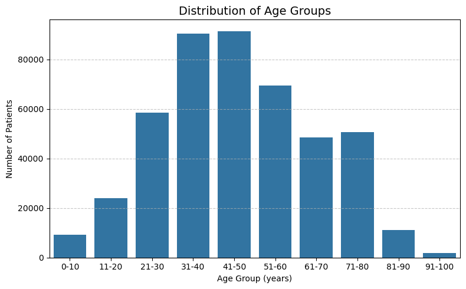

```python
# Map string codes back to age ranges and Define correct order
age_map = {
    0: '0-10',
    1: '11-20',
    2: '21-30',
    3: '31-40',
    4: '41-50',
    5: '51-60',
    6: '61-70',
    7: '71-80',
    8: '81-90',
    9: '91-100'
}

df_encoded['Age_label'] = df_encoded['Age'].map(age_map)

age_order = list(age_map.values())

plt.figure(figsize=(8, 5))
sns.countplot(
    x='Age_label',
    data=df_encoded,
    order=age_order
)
plt.title("Distribution of Age Groups", fontsize=14)
plt.xlabel("Age Group (years)")
plt.ylabel("Number of Patients")
plt.xticks(rotation=0)
plt.grid(axis='y', linestyle='--', alpha=0.7)
plt.tight_layout()
plt.show()
```

The distribution of Age shows that the majority of patients belong to the 31–60 age group. The number of hospital admissions gradually decreases for both younger and older age groups, with the fewest patients under 10 and over 90 years old.

##### Patient City Code

```
Number of unique city codes: 37

Top 10 most common city codes:

City_Code_Patient
7     183514
1      55681
0      37772
6      33958
4      28978
3      22044
8      16692
14     12804
9      11809
5       8723
Name: count, dtype: int64
```

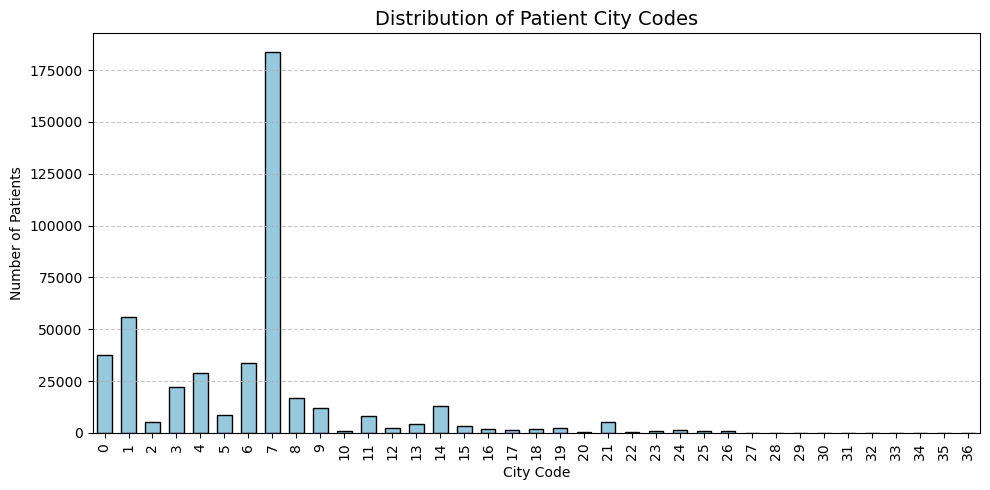

```python
print("Number of unique city codes:", df_encoded['City_Code_Patient'].nunique())
print("\nTop 10 most common city codes:\n")
print(df_encoded['City_Code_Patient'].value_counts().head(10))

plt.figure(figsize=(10,5))
sns.countplot(
    x='City_Code_Patient',
    data=df_encoded,
    color='skyblue',
    edgecolor='black',
    width=0.6
)
plt.title("Distribution of Patient City Codes", fontsize=14)
plt.xlabel("City Code")
plt.ylabel("Number of Patients")
plt.xticks(rotation=90)
plt.grid(axis='y', linestyle='--', alpha=0.7)
plt.tight_layout()
plt.show()
```

The variable City_Code_Patient contains 37 unique city codes, indicating that there is geographical spread of patients across different locations.

#### Numerical Variables Analysis

##### Available Extra Rooms in Hospital

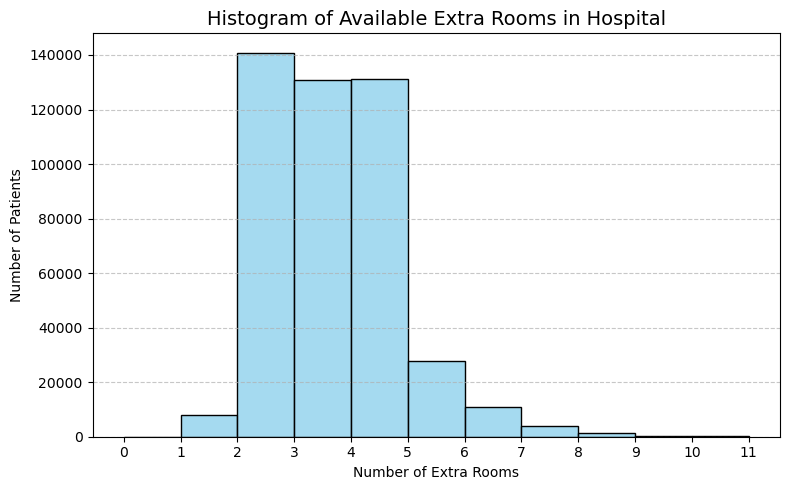

```python
plt.figure(figsize=(8,5))
sns.histplot(df_encoded['Available Extra Rooms in Hospital'], bins=range(0,12), color='skyblue', edgecolor='black')
plt.title("Histogram of Available Extra Rooms in Hospital", fontsize=14)
plt.xlabel("Number of Extra Rooms")
plt.ylabel("Number of Patients")
plt.xticks(range(0,12))
plt.grid(axis='y', linestyle='--', alpha=0.7)
plt.tight_layout()
plt.show()
```

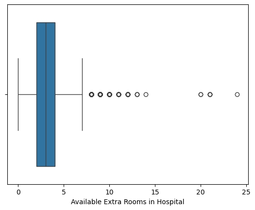

```python
sns.boxplot(x=df_encoded['Available Extra Rooms in Hospital'])
```

The distribution of Available Extra Rooms in Hospital shows that most hospitals have between zero and five additional rooms

However, a few hospitals report a much higher number of available rooms, which could mean that there are either larger healthcare facilities or possible data anomalies in the dataset

##### Visitors with Patient

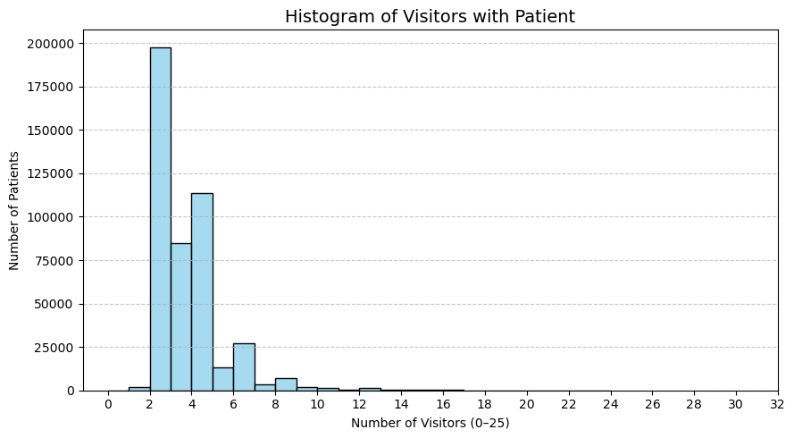

```python
plt.figure(figsize=(9,5))
sns.histplot(df_encoded['Visitors with Patient'], bins=range(0, 25), color='skyblue', edgecolor='black')
plt.title("Histogram of Visitors with Patient", fontsize=14)
plt.xlabel("Number of Visitors (0–25)")
plt.ylabel("Number of Patients")
plt.xticks(range(0, 33, 2))
plt.grid(axis='y', linestyle='--', alpha=0.7)
plt.tight_layout()
plt.show()
```

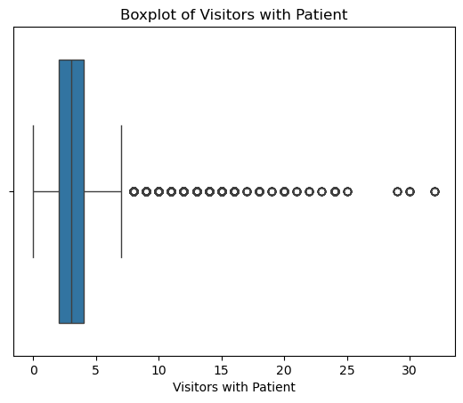

```python
sns.boxplot(x=df_encoded['Visitors with Patient'])
plt.title("Boxplot of Visitors with Patient")
plt.show()
```

The distribution of Visitors with Patient is right-skewed, indicating that most patients receive between 1 and 5 visitors.

A small number of records show unusually high visitor counts which is up to 30. This could either reflect data entry errors or exceptional circumstances involving specific patients.

##### Admission Deposit Distribution

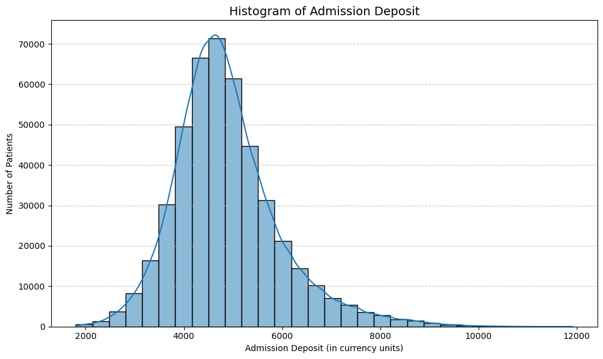

```python
plt.figure(figsize=(10, 6))
sns.histplot(df_encoded['Admission_Deposit'], kde=True, bins=30)
plt.title("Histogram of Admission Deposit", fontsize=14)
plt.xlabel("Admission Deposit (in currency units)")
plt.ylabel("Number of Patients")
plt.grid(axis='y', linestyle='--', alpha=0.7)
plt.tight_layout()
plt.show()
```

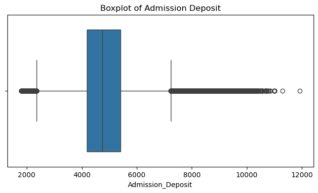

```python
plt.figure(figsize=(8,4))
sns.boxplot(x=df_encoded['Admission_Deposit'])
plt.title("Boxplot of Admission Deposit")
plt.show()
```

The distribution of Admission_Deposit is right-skewed, with the majority of deposits falling between 3,000 and 6,000 units.

A few patients made significantly higher deposits which is up to 12,000, appearing as outliers in the dataset. These values may indicate special patient cases or possible data entry inconsistencies.

### 3.3 Bivariate Analysis

In this section we compute and visualize the correlation between the features themselves, as well as the correlation between each feature and the target variable ‘Stay’.

This analysis may help in developing a more accurate prediction model for the Length of Stay (LOS), by potentially ignoring features which are either highly correlated with eachother, or features with little to no correlation with the target.

#### Admission Deposit

This section visualizes the relationship between Admission Deposit and Length of Stay using a regression plot. The plot helps to observe whether higher admission deposits are associated with longer hospital stays.

The y-axis values are mapped to the predefined ordinal categories of Stay, providing a clear interpretation of how deposit amounts vary across different stay durations.

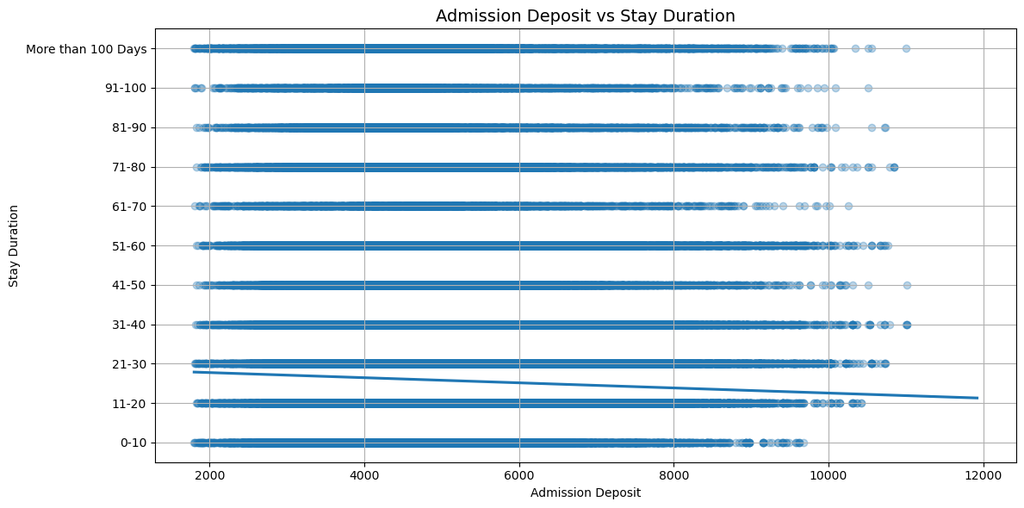

```python
import matplotlib.pyplot as plt
import seaborn as sns

stay_order = ordinal_orders['Stay']

plt.figure(figsize=(12, 6))
sns.regplot(
    x='Admission_Deposit',
    y='Stay',
    data=df_encoded,
    scatter_kws={'alpha': 0.3},
    ci=None
)
plt.title('Admission Deposit vs Stay Duration', fontsize=14)
plt.xlabel('Admission Deposit')
plt.ylabel('Stay Duration')
plt.grid(True)

plt.yticks(ticks=range(len(stay_order)), labels=stay_order)
plt.ylim(-0.5, len(stay_order)-0.5)

plt.tight_layout()
plt.show()
```

The visualization indicates that admission deposit amounts are fairly evenly distributed across all stay duration categories.There is no clear increasing or decreasing trend, suggesting that higher deposits do not correspond to longer hospital stays.

Overall, the relationship between Admission Deposit and Length of Stay is weak, implying that deposit amount is not a strong predictor of how long a patient remains in the hospital.

#### Patient Age

This section explores the relationship between Age Group and Length of Stay using a boxplot. Encoded age values are mapped back to their original categorical labels to ensure readability. The visualization helps identify how patient age groups correspond to hospital stay duration, highlighting whether certain age ranges tend to have longer or shorter stays on average.

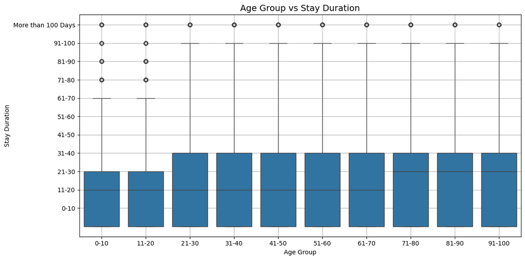

```python
stay_order = ordinal_orders['Stay']

df_encoded['Age_label'] = df_encoded['Age'].map({i: label for i, label in enumerate(age_order)})
df_encoded['Age_label'] = pd.Categorical(df_encoded['Age_label'],categories=age_order, ordered=True)

plt.figure(figsize=(12, 6))
sns.boxplot(x='Age_label', y='Stay', data=df_encoded, order=age_order)
plt.title("Age Group vs Stay Duration", fontsize=14)
plt.xlabel("Age Group")
plt.ylabel("Stay Duration")
plt.grid(True)

plt.yticks(ticks=range(len(stay_order)), labels=stay_order)

plt.tight_layout()
plt.show()
```

The boxplot indicates that average hospital stay tends to increase with patient age.Older patients, generally experience longer stays compared to younger age groups. This could suggests that there is a positive association between age and Length of Stay, meaning that age is an important factor influencing how long patients remain in the hospital.

#### Severity of Illness

This section examines the relationship between Severity of Illness and Length of Stay using a boxplot. The visualization helps to identify whether patients with more severe illnesses tend to have longer hospital stays.

Numeric codes for both Stay and Severity of Illness are mapped to readable labels, allowing for a clear comparison across severity levels.

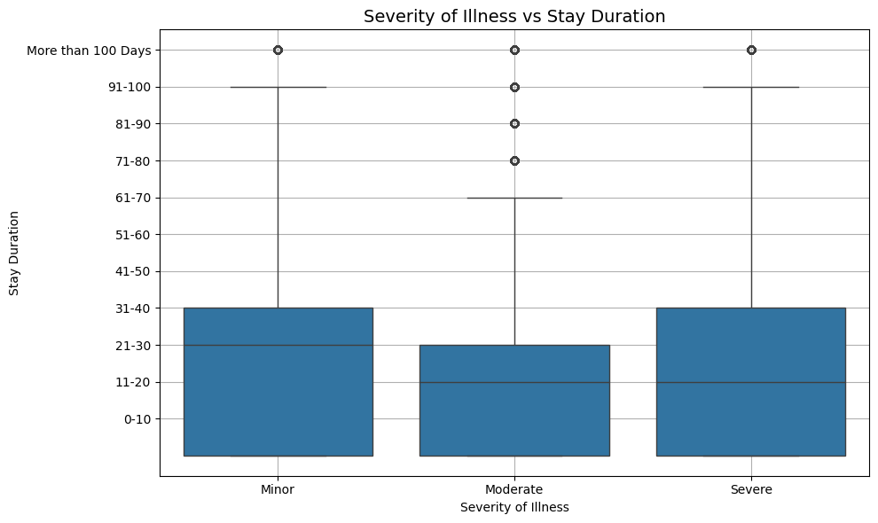

```python
stay_order = ordinal_orders['Stay']
severity_order = ordinal_orders['Severity of Illness']
plt.figure(figsize=(10, 6))
sns.boxplot(x='Severity of Illness', y='Stay', data=df_encoded)
plt.title("Severity of Illness vs Stay Duration", fontsize=14)
plt.xlabel("Severity of Illness")
plt.ylabel("Stay Duration")
plt.grid(True)

plt.yticks(ticks=range(len(stay_order)), labels=stay_order)
plt.xticks(ticks=range(len(severity_order)), labels=severity_order)

plt.tight_layout()
plt.show()
```

#### Admission Type

This section analyzes the relationship between Type of Admission and Length of Stay using a boxplot. Encoded admission types are mapped back to readable labels for clarity.he visualization allows us to compare how different admission types are associated with hospital stay duration, highlighting whether certain types of admissions tend to result in longer stays.

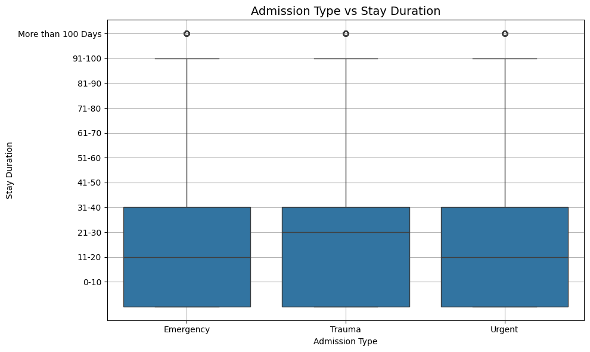

```python
stay_order = ordinal_orders['Stay']
Type_of_Admission_order = df['Type of Admission'].astype('category').cat.categories.tolist()

df_encoded['AdmissionType_label'] = df_encoded['Type of Admission'].map({i:label for i, label in enumerate(Type_of_Admission_order)})
df_encoded['AdmissionType_label'] = pd.Categorical(df_encoded['AdmissionType_label'],categories=Type_of_Admission_order, ordered=True)

plt.figure(figsize=(10,6))
sns.boxplot(x='AdmissionType_label', y='Stay', data=df_encoded, order=Type_of_Admission_order)
plt.title("Admission Type vs Stay Duration", fontsize=14)
plt.xlabel("Admission Type")
plt.ylabel("Stay Duration")
plt.grid(True)

plt.yticks(ticks=range(len(stay_order)), labels=stay_order)

plt.tight_layout()
plt.show()
```

The boxplot shows that the median stay for the trauma group is higher, though the overall spread of stay durations is similar across all admission types. This suggests that admission type has a limited but noticeable effect on stay duration.

#### Visitors with patient

This section examines the relationship between the number of visitors with a patient and Length of Stay using a boxplot.The number of visitors is grouped into categories for clarity. This will help identify whether patients with more visitors tend to have longer or shorter hospital stays, providing insights into potential factors affecting recovery.

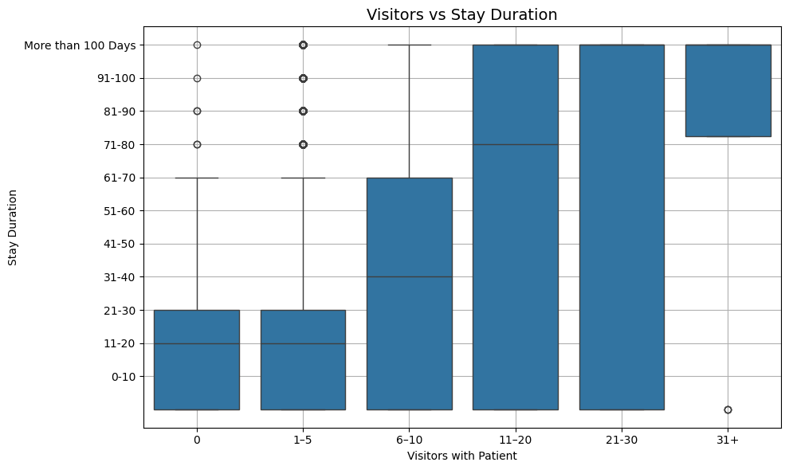

```python
stay_order = ordinal_orders['Stay']

df_encoded['Visitor_Group'] = pd.cut(
    df_encoded['Visitors with Patient'],
    bins=[0, 1, 5, 10, 20, 30, 35],
    labels=['0', '1–5', '6–10', '11–20','21-30', '31+']
    )

plt.figure(figsize=(10, 6))
sns.boxplot(x='Visitor_Group', y='Stay', data=df_encoded)
plt.title("Visitors vs Stay Duration", fontsize=14)
plt.xlabel("Visitors with Patient")
plt.ylabel("Stay Duration")
plt.grid(True)

plt.yticks(ticks=range(len(stay_order)), labels=stay_order)

plt.tight_layout()
plt.show()
```

The chart illustrates that patients with longer stay durations tend to have a higher number of visitors. This relationship is likley to be explained by exposure time rather than a negative causal effect of social support on recovery speed. The pattern of more visitors during long stay durations therefore simply reflects a greater opportunity for visits during extended hospitalisations.

#### Available Rooms

This section will use boxplot to see the relationship between Available Extra Rooms in Hospital and Length of Stay. It will help to determine whether the number of available rooms in a hospital is associated with longer or shorter patient stays.

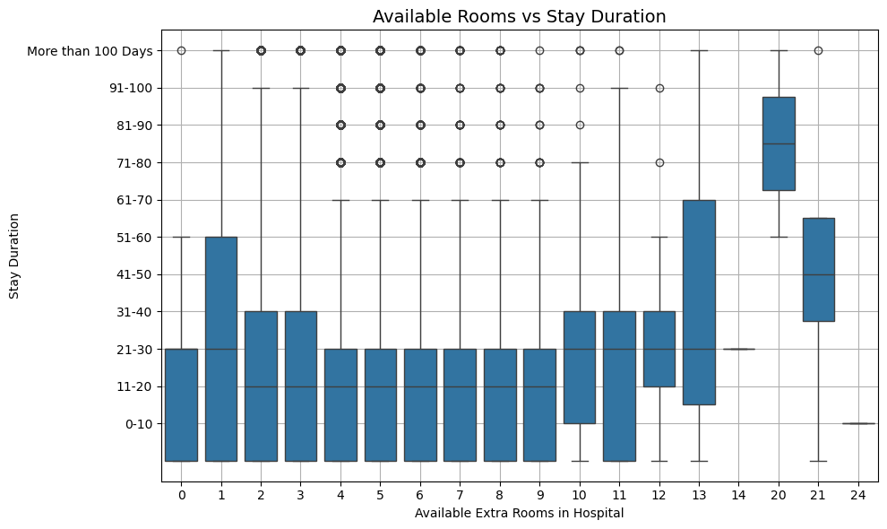

```python
plt.figure(figsize=(10, 6))
sns.boxplot(x='Available Extra Rooms in Hospital', y='Stay', data=df_encoded)
plt.title("Available Rooms vs Stay Duration", fontsize=14)
plt.xlabel("Available Extra Rooms in Hospital")
plt.ylabel("Stay Duration")
plt.grid(True)

plt.yticks(ticks=range(len(stay_order)), labels=stay_order)

plt.tight_layout()
plt.show()
```

The boxplot does show no significant relation between the number of available rooms and the indivisual length of stay per case. Most cases regardless of room availability present with a similar median stay duration (10 . 30 days). Slightly longer stays occur where more extra rooms were available which may indicate lower occupancy or coincidental variation.

#### Bed grade

This section verifies the mapping between raw and encoded values for the variable Bed Grade. By comparing the original labels with their encoded versions, we can see if that categorical encoding has been applied correctly before using the variable in visualizations or modeling.

Here will explored the relationship between Bed Grade and Length of Stay using a boxplot. The encoded bed grades are mapped back to readable labels for clarity, allowing us to observe whether patients in higher or lower bed grades tend to have longer or shorter hospital stays.

```python
df_compare = df[['Bed Grade']].copy()
df_compare['Encoded'] = df_encoded['Bed Grade']
df_compare.drop_duplicates().sort_values('Encoded')
```

|  | Bed Grade | Encoded |
| --- | --- | --- |
| 11 | 1.0 | 0 |
| 0 | 2.0 | 1 |
| 293 | NaN | 1 |
| 6 | 3.0 | 2 |
| 8 | 4.0 | 3 |

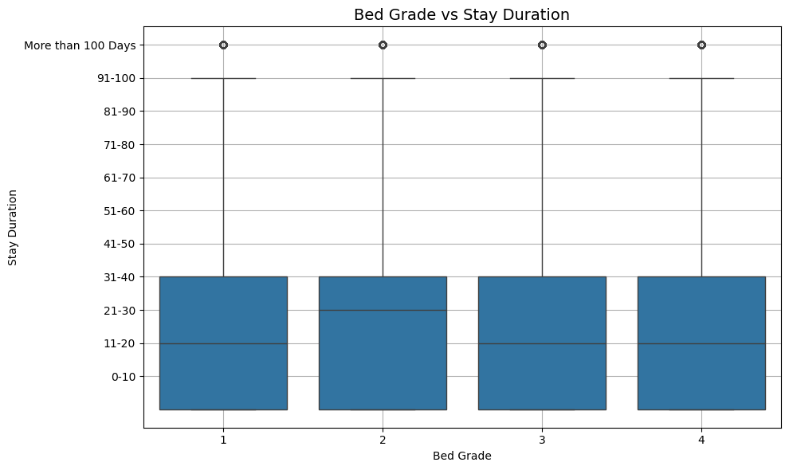

```python
stay_order = ordinal_orders['Stay']
Bed_Grade_order = ordinal_orders['Bed Grade']

df_encoded['BedGrade_label'] = df_encoded['Bed Grade'].map({i:label for i, label in enumerate(Bed_Grade_order)})
df_encoded['BedGrade_label'] = pd.Categorical(df_encoded['BedGrade_label'],categories=Bed_Grade_order, ordered=True)

plt.figure(figsize=(10, 6))
sns.boxplot(x='BedGrade_label', y='Stay', data=df_encoded)
plt.title("Bed Grade vs Stay Duration", fontsize=14)
plt.xlabel("Bed Grade")
plt.ylabel("Stay Duration")
plt.grid(True)

plt.yticks(ticks=range(len(stay_order)), labels=stay_order)

plt.tight_layout()
plt.show()
```

The boxplot shows that hospital bed grade has little impact on the length of stay. The median and distribution of stay durations are very similar across all bed grades.

#### Department

Here will be examined the relationship between Department and Length of Stay using a boxplot. Encoded department values are mapped back to readable labels for clarity.

It will allow to compare how patients in different hospital departments correspond to varying stay durations, highlighting whether certain departments tend to have longer or shorter hospital stays on average.

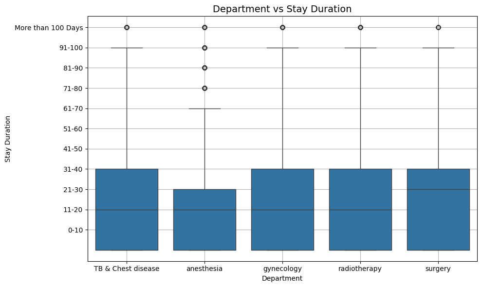

```python
stay_order = ordinal_orders['Stay']
Department_order = df['Department'].astype('category').cat.categories.tolist()

df_encoded['Department_label'] = df_encoded['Department'].map({i:label for i, label in enumerate(Department_order)})
df_encoded['Department_label'] = pd.Categorical(df_encoded['Department_label'],categories=Department_order, ordered=True)

plt.figure(figsize=(10, 6))
sns.boxplot(x='Department_label', y='Stay', data=df_encoded)
plt.title("Department vs Stay Duration", fontsize=14)
plt.xlabel("Department")
plt.ylabel("Stay Duration")
plt.grid(True)

plt.yticks(ticks=range(len(stay_order)), labels=stay_order)

plt.tight_layout()
plt.show()
```

#### Ward type

This section verifies the mapping between raw and encoded values for the variable Ward_Type to ensure that categorical encoding is correct. Here is explored the relationship between Ward Type and Length of Stay using a boxplot.

```python
comparison = pd.DataFrame({
    'Original': df['Ward_Type'],
    'Encoded': df_encoded['Ward_Type']
}).drop_duplicates().sort_values('Encoded')

print(comparison)
```

```
      Original  Encoded
99           P        0
7            Q        1
0            R        2
1            S        3
234          T        4
46873        U        5
```

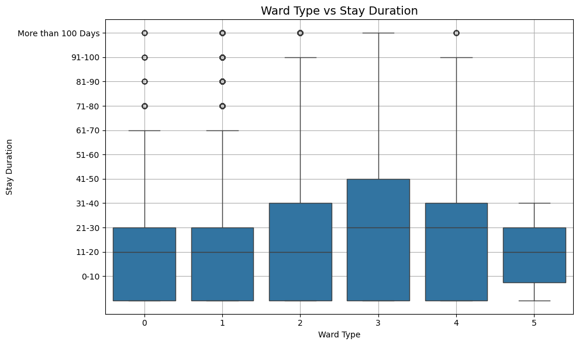

```python
stay_order = ordinal_orders['Stay']
Ward_Type_order = df_encoded['Ward_Type'].astype('category').cat.categories.tolist()

df_encoded['Ward_Type_label'] = df_encoded['Ward_Type'].map({i:label for i, label in enumerate(Ward_Type_order)})
df_encoded['Ward_Type_label'] = pd.Categorical(df_encoded['Ward_Type_label'],categories=Ward_Type_order, ordered=True)

plt.figure(figsize=(10, 6))
sns.boxplot(x='Ward_Type_label', y='Stay', data=df_encoded)
plt.title("Ward Type vs Stay Duration", fontsize=14)
plt.xlabel("Ward Type")
plt.ylabel("Stay Duration")
plt.grid(True)

plt.yticks(ticks=range(len(stay_order)), labels=stay_order)

plt.tight_layout()
plt.show()
```

The boxplot shows clear differences in stay duration among ward types.Patients in ward type S and T tend to have longer hospital stays, with higher medians and wider ranges. In contrast, ward types P, Q, and U show shorter and more concentrated stay durations.

### 3.4 Correlation Analysis

#### Multicolinearity Check

In this section we perform multicollinearity check among the features to identify potentially redundant predictors.

Identifying such feature pairs is important for model building, as removing or combining highly correlated predictors can improve model stability and reduce multicollinearity issues.

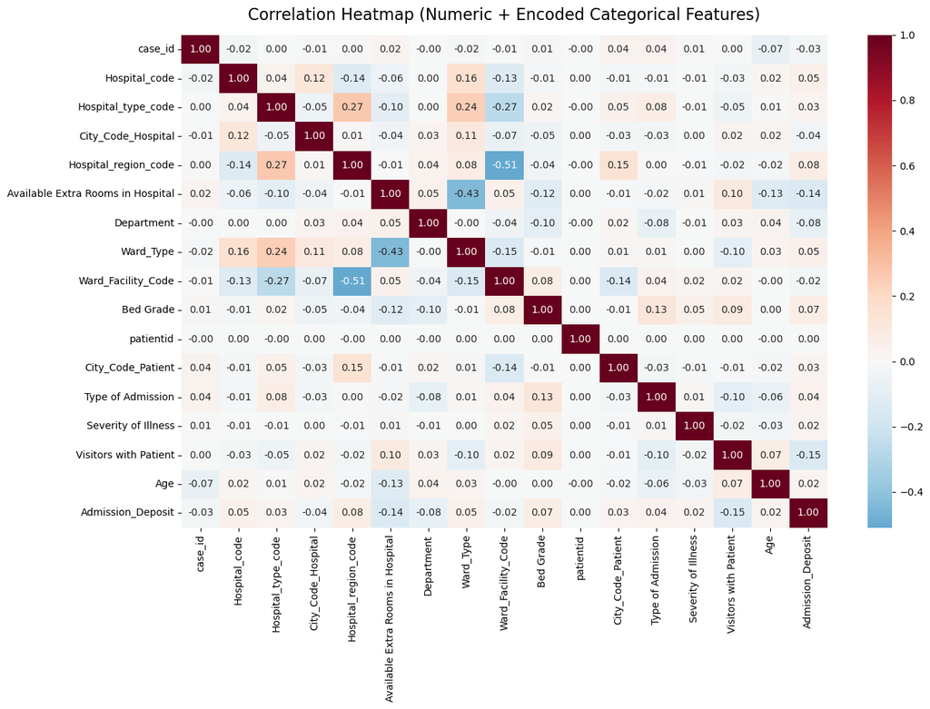

```python
# Select only numeric columns from the features list
# (dropping labels added for visualisation of categorical variables in previous sections)
corr_features = (
    df_encoded[features]
    .select_dtypes(include=['number'])
    .corr(method='pearson')
)

plt.figure(figsize=(14, 10))
sns.heatmap(corr_features,
    annot=True,
    cmap='RdBu_r',
    center=0,
    fmt=".2f",
)
plt.title(
    "Correlation Heatmap (Numeric + Encoded Categorical Features)",
    fontsize=16,
    pad=15
)
plt.tight_layout()
plt.show()
```

```python
# --- Detect highly correlated feature pairs ---
# Set correlation threshold
threshold = 0.8

# Get absolute values (since negative correlation also matters)
corr_matrix_abs = corr_features.abs()

# Create a mask to ignore self-correlations
upper_tri = corr_matrix_abs.where(
    np.triu(np.ones(corr_matrix_abs.shape), k=1).astype(bool)
)

# Find features with correlation greater than threshold
high_corr_pairs = [
    (col, row, upper_tri.loc[row, col])
    for col in upper_tri.columns
    for row in upper_tri.index
    if not pd.isna(upper_tri.loc[row, col]) and upper_tri.loc[row, col] > threshold
]

# Convert to DataFrame for easy viewing
high_corr_df = pd.DataFrame(high_corr_pairs, columns=['Feature_1', 'Feature_2', 'Correlation'])

print("Highly correlated feature pairs (|r| > {:.2f}):".format(threshold))
print(high_corr_df.sort_values(by='Correlation', ascending=False))
```

```
Highly correlated feature pairs (|r| > 0.80):
Empty DataFrame
Columns: [Feature_1, Feature_2, Correlation]
Index: []
```

There seems to be no significant correlation between features.

#### Correlation Between Features and Target

We will now examine the correlation between each feature and the target variable Length of Stay, to identify features that are weakly related or potentially irrelevant.

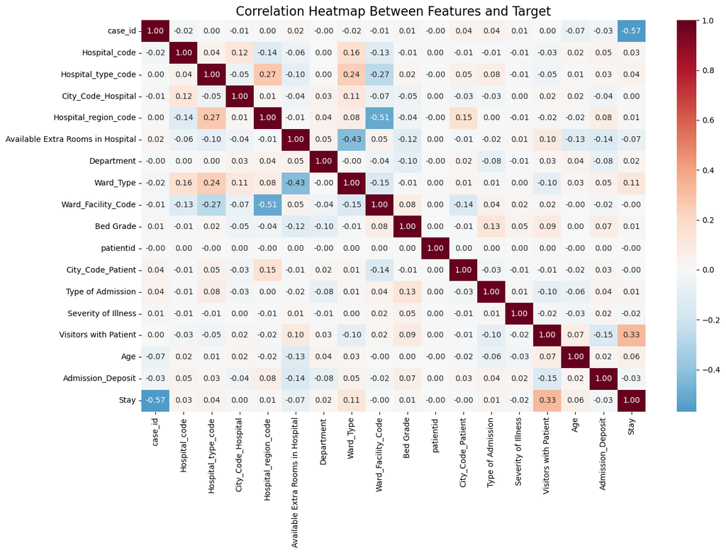

```python
# Drop rows where LOS is missing
df_no_missing = df_encoded.dropna(subset=[target])

# Compute correlation matrix only for numeric columns (to exclude labels added for visualisation purposes)
corr_target = df_no_missing.select_dtypes(include='number').corr(method='pearson')

plt.figure(figsize=(14, 10))
sns.heatmap(corr_target, annot=True, cmap='RdBu_r', center=0, fmt=".2f")
plt.title("Correlation Heatmap Between Features and Target", fontsize=16)
plt.tight_layout()
plt.show()
```

The correlation heatmap shows that most variables have weak correlations with the target variable Stay.

##### Top Features Correlated with Length of Stay:

In this section we sort the correlations by absolute value, highlighting the variables that are most strongly associated with Length of Stay.

A bar plot is created to visualize the top 10 features with the highest correlation coefficients, providing a clear view of the predictors most relevant for modeling hospital stay duration.

```
Correlation of each variable with Stay (sorted by absolute value):
Visitors with Patient                0.326079
Ward_Type                            0.113250
Available Extra Rooms in Hospital   -0.072398
Age                                  0.057824
Hospital_type_code                   0.035932
Admission_Deposit                   -0.028525
Hospital_code                        0.025147
Department                           0.019776
Severity of Illness                 -0.018903
Type of Admission                    0.014207
Bed Grade                            0.012489
Hospital_region_code                 0.006729
City_Code_Patient                   -0.004561
Ward_Facility_Code                  -0.002792
City_Code_Hospital                   0.002666
patientid                           -0.000396
Name: Stay, dtype: float64
```

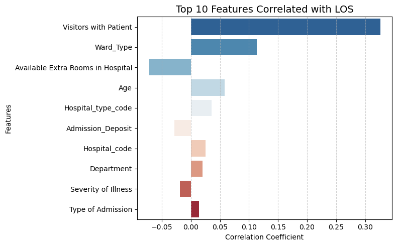

```python
stay_corr = (
    # If corr_target is a DataFrame:
    #   select the column corresponding to the target to get correlations as a Series
    #   then drop the self-correlation of the target
    corr_target[target].drop(labels=[target], errors='ignore')
    # Else, if corr_target is already a Series:
    #   just drop the self-correlation of the target
    if isinstance(corr_target, pd.DataFrame)
    else corr_target.drop(labels=[target], errors='ignore')
)

# Drop irrelevant column
stay_corr = stay_corr.drop('case_id', errors='ignore')

# Sort by absolute value
stay_corr_sorted = stay_corr.reindex(stay_corr.abs().sort_values(ascending=False).index)

print("Correlation of each variable with Stay (sorted by absolute value):")
print(stay_corr_sorted)

# --- Visualize top correlated variables ---
plt.figure(figsize=(8, 5))
sns.barplot(
    x=stay_corr_sorted.head(10),
    y=stay_corr_sorted.head(10).index,
    palette="RdBu_r"
)
plt.title("Top 10 Features Correlated with LOS", fontsize=14)
plt.xlabel("Correlation Coefficient")
plt.ylabel("Features")
plt.grid(axis='x', linestyle='--', alpha=0.6)
plt.tight_layout()
plt.show()
```

The bar chart shows the top ten features most correlated with hospital stay duration. As shown in the correlation Heatmap, Visitors with Patient has the strongest correlation, followed by Ward_Type and Available Extra Rooms in Hospital.

Overall, the correlations are relatively weak for most variables, suggesting that hospital stay may be influenced by multiple interacting factors rather than a single dominant variable. or that the features' influence on stay length may be nonlinear or indirect. For this reason, we have decided to not exclude any of the features from our models.

## 4. Data Cleaning & Preprocessing

We will now make the dataset ready for modeling. To do so, we will:

#### 4.1 Split Data into Test and Validation Sets

##### Feature Type Definition

First, we define the types of columns in the dataset — distinguishing between quantitative (numerical) and qualitative (categorical) features. This helps us determine the appropriate preprocessing and encoding techniques for each type.

1. **Numerical Features** (Quantitative)

These are features that represent measurable quantities — values on a continuous or discrete numerical scale.

2. **Categorical Features** (Qualitative)

These represent labels or groups rather than numeric quantities. They are further divided into subtypes:

- *Ordinal Features*: Categorical features that have a natural order or ranking, but the intervals between categories are not necessarily equal.
- *Nominal Features with Low Cardinality*: Categorical features with no intrinsic order and a small number of unique categories (here fewer than 10).
- *Nominal Features with High Cardinality*: Categorical features with many unique categories (here more than 10).

A different strategy will be used for each of these feature/columns types (see section 4.3).

```python
# Define numeric features
numeric_features = ['Available Extra Rooms in Hospital', 'Visitors with Patient', 'Admission_Deposit']

# Define all categorical features
categorical_features = [
    'Hospital_code', 'Hospital_type_code', 'City_Code_Hospital',
    'Hospital_region_code', 'Department', 'Ward_Type',
    'Ward_Facility_Code', 'Bed Grade', 'City_Code_Patient',
    'Type of Admission', 'Severity of Illness', 'Age'
]

# Define ordinal features
ordinal_features = ['Bed Grade', 'Severity of Illness', 'Age']

#Define nominal features
nominal_features = list(set(categorical_features) - set(ordinal_features))
print("Non-ordinal categorical features: ", nominal_features)

# Detect nominal features with high-cardinality
HIGH_CARDINALITY_THRESHOLD = 10
high_card_features = [
    (col, df[col].nunique())
    for col in nominal_features
    if df[col].nunique() > HIGH_CARDINALITY_THRESHOLD
]

# Separate low/high-cardinality nominal columns
low_card_features = [col for col in nominal_features if col not in [c for c, _ in high_card_features]]
high_card_features_names = [col for col, _ in high_card_features]

print("High-cardinality features:", high_card_features_names)
print("Low-cardinality features: ",low_card_features)
```

```
Non-ordinal categorical features:  ['Type of Admission', 'Hospital_code', 'Ward_Type', 'Ward_Facility_Code', 'Department', 'City_Code_Patient', 'Hospital_type_code', 'Hospital_region_code', 'City_Code_Hospital']
High-cardinality features: ['Hospital_code', 'City_Code_Patient', 'City_Code_Hospital']
Low-cardinality features:  ['Type of Admission', 'Ward_Type', 'Ward_Facility_Code', 'Department', 'Hospital_type_code', 'Hospital_region_code']
```

##### Splitting the Data into Training, Validation and Test Sets

We will now split the data into training, validation and test sets as follows:

- **Training set** represents 60% of total data,
- **Validation set** 20% represents of total data,
- **Test set** 20% represents of total data.

```python
# Define target column
target_col = 'Stay'

# Define columns to exclude from X
exclude_cols = ['patientid', 'case_id', target_col] # Exclude LOS (target) + IDS columns to avoid data leakage

# Create feature matrix X and target y
X = df.drop(columns=exclude_cols)
y = df[target_col].astype('object') # make sure target data type is categorical

# Convert only existing categorical columns in X to object dtype
cols_to_convert = [col for col in categorical_features if col in X.columns]
X[cols_to_convert] = X[cols_to_convert].astype('object')

# First split into (train + val) and test sets - 80% (train + val), 20% test
X_train_val, X_test, y_train_val, y_test = train_test_split(
    X, y,
    test_size=0.2,
    random_state=42,
    stratify=None  # or use stratify=y if your target is categorical/imbalanced
)

# Then split again (train + val) into train and validation sets - 75% train, 25% val of remaining 80%
X_train, X_val, y_train, y_val = train_test_split(
    X_train_val, y_train_val,
    test_size=0.25,  # 0.25 * 0.8 = 0.2 of original data for validation
    random_state=42,
    stratify=None
)

print(f"Train size: {X_train.shape[0]}")
print(f"Validation size: {X_val.shape[0]}")
print(f"Test size: {X_test.shape[0]}")
```

```
Train size: 273297
Validation size: 91099
Test size: 91099
```

### 4.2 Target Data Preparation

The target variable (Length of Stay) requires preprocessing prior to model training. This includes handling missing observations and transforming the variable through ordinal encoding to ensure it is numerically interpretable by the learning algorithm.

#### Missing Values

We first ensure that the training, validation, and test sets contain no missing values in the target variable Length of Stay. Observations lacking a recorded Length value must be excluded prior to model training, as supervised learning algorithms require known target outputs to learn from.

```python
# ----------------------- Drop rows with missing target -----------------------
# In the Training set
train_mask = y_train.notnull()      # True for rows where y_train is not NaN
X_train = X_train[train_mask]       # Keep only rows with non-null target in X_train
y_train = y_train[train_mask]       # Keep only rows with non-null target in y_train

# In the Validation set
val_mask = y_val.notnull()
X_val = X_val[val_mask]
y_val = y_val[val_mask]

# In the Test set
test_mask = y_test.notnull()
X_test = X_test[test_mask]
y_test = y_test[test_mask]

# ----------------------- Sanity check -----------------------
print("Training set size after dropping NaNs in target:", X_train.shape[0])
print("Validation set size after dropping NaNs in target:", X_val.shape[0])
print("Test set size after dropping NaNs in target:", X_test.shape[0])

print("Any missing values left in y_train?", y_train.isnull().any())
print("Any missing values left in y_val?", y_val.isnull().any())
print("Any missing values left in y_test?", y_test.isnull().any())
```

```
Training set size after dropping NaNs in target: 190994
Validation set size after dropping NaNs in target: 63888
Test set size after dropping NaNs in target: 63556
Any missing values left in y_train? False
Any missing values left in y_val? False
Any missing values left in y_test? False
```

#### Categorical Data Ordinal Encoding

aWe then encode the target variable Length of Stay as an ordinal variable suitable for modeling. The target variable must be ordinally encoded prior to model input. The Length of stay ranges are mapped to integer values from 0 to 10, reflecting their sequential order based on length of stay.

```python
# ----------------------- Encode target as ordinal -----------------------
target_encoder = OrdinalEncoder()

# Fit on training target and transform
y_train_encoded = target_encoder.fit_transform(y_train.values.reshape(-1, 1)).ravel()

# Transform validation and test targets
y_val_encoded = target_encoder.transform(y_val.values.reshape(-1, 1)).ravel()
y_test_encoded = target_encoder.transform(y_test.values.reshape(-1, 1)).ravel()

# ----------------------- Display mapping -----------------------
mapping = dict(zip(target_encoder.categories_[0], range(len(target_encoder.categories_[0]))))
print("Ordinal mapping of target classes:", mapping)
```

```
Ordinal mapping of target classes: {'0-10': 0, '11-20': 1, '21-30': 2, '31-40': 3, '41-50': 4, '51-60': 5, '61-70': 6, '71-80': 7, '81-90': 8, '91-100': 9, 'More than 100 Days': 10}
```

### 4.3 Features Preprocessing

Here we define our Pipelines for preprocessing. We have chosen the following strategies:

1. **Numeric features**: Missing values in numerical feature columns are replaced with **median**, and the features are subsequently **standardized** to ensure consistent scaling and prevent distortion of model results
2. **Categorical features**:
- **Ordinal features**: Missing values are imputed with the **mode**, and the feature is **ordinally encoded** to preserve its natural order.
- **Low-cardinality nominal features**: Missing values are imputed with the **mode**, and the feature is encoded using **one-hot encoding**.
- **High-cardinality nominal features**: Missing values are imputed with the **mode**, and the feature is encoded using **target encoding** to avoid the curse of dimensionality, which can occur when one-hot encoding creates an excessively large dataset that is computationally expensive to process.

```python
# --- Define transformers ---
numeric_transformer = Pipeline([
    ('imputer', SimpleImputer(strategy='median')), # Replace missing values with median
    ('scaler', StandardScaler()) # Standardize data
])

ordinal_transformer = Pipeline([
    ('imputer', SimpleImputer(strategy='most_frequent')), # Replace missing values with mode
    ('encoder', OrdinalEncoder()) # Apply ordinal encoding
])

low_card_transformer = Pipeline([
    ('imputer', SimpleImputer(strategy='most_frequent')), # Replace missing values with mode
    ('encoder', OneHotEncoder(handle_unknown='ignore', sparse_output=False)) # Apply one-hot encoding
])

high_card_transformer = Pipeline([
    ('imputer', SimpleImputer(strategy='most_frequent')), # Replace missing values with mode
    ('encoder', TargetEncoder())  # # Apply target encoding, which requires y_train when fitting
])

# --- Combine transformers conditionally ---
transformers = [
    ('num', numeric_transformer, numeric_features), # Use numeric_transformer on numeric features
    ('ord', ordinal_transformer, ordinal_features) # Use ordinal_transformer on ordinal features
]

if low_card_features:
    transformers.append(('low_card_cat', low_card_transformer, low_card_features)) # Use low_card_transformer on low-cardinality nominal features
if high_card_features_names:
    transformers.append(('high_card_cat', high_card_transformer, high_card_features_names)) # Use high_card_transformer on high-cardinality nominal features

# Define Preprocessor
preprocessor = ColumnTransformer(transformers=transformers)
```

## 5. Model Selection

### 5.1 Models Definition

We have selected five models to train. Here is a table below listing each model's strengths and limitations relevant for this project.

| Model | Strength | Limitations |
| --- | --- | --- |
| Decision Tree | Handles categorical features and non-linear relationships | Prone to overfitting, unstable on small changes in data |
| Random Forest | Reduces overfitting by averaging trees, good generalization | Treats ordinal info as categorical unless encoded carefully |
| Logistic Regression | Fast, works well for baseline classification | Cannot capture non-linear relationships well, requires feature scaling |
| OGBoost | Specifically designed for ordinal targets | Relatively new, may require more tuning and larger data for stability |
| LightGBM | Efficient gradient boosting, handles large datasets, fast training | Less interpretable, but strong predictive power |

We define a dictionary containing all 5 models set with default parameters, some of which will be overridden during hyperparameter tuning. This is A set of classification models wrapped in pipelines for consistent preprocessing and fair comparison. Includes Decision Tree, Random Forest, OGBoost, Logistic Regression, and LightGBM to balance interpretability and performance.

```python
# Create model dictionary
models = {}

# Define Decision Tree model (classification)
models["Decision Tree"] = Pipeline([
    ("preprocess", preprocessor), # Use the preprocessing pipeline defined earlier
    ("clf", DecisionTreeClassifier(max_depth=None, random_state=42)) # Define the model itself and default parameters
])

# Random Forest (classification)
models["Random Forest"] = Pipeline([
    ("preprocess", preprocessor),
    ("clf", RandomForestClassifier(n_estimators=200, random_state=42))
])

# OGBoost (Gradient Boosting Ordinal), better performing than XGBoost for ordinal tasks
models["OGBoost"] = Pipeline([
    ("preprocess", preprocessor),
    ("ord", GradientBoostingOrdinal(
        n_estimators=100,
        learning_rate=0.1,
        random_state=42
    ))
])

# Logistic Regression (classification)
models["Logistic Regression"] = Pipeline([
    ("preprocess", preprocessor),
    ("clf", LogisticRegression(
        max_iter=2000,
        solver='saga',
        multi_class='multinomial',
        C=1.0,
        random_state=42
    ))
])

# LightGBM (classification)
models["LightGBM"] = Pipeline([
    ("preprocess", preprocessor),
    ("clf", LGBMClassifier(
        n_estimators=200,
        learning_rate=0.1,
        random_state=42
    ))
])
```

### 5.2 Model Hyperparameter Tuning

#### Helper Functions to Evaluate Models

Model Evaluation Metrics

We selected **accuracy** as one of the metrics to evaluate model performance. Accuracy measures the fraction of exact matches between the predicted and true LOS values.

However, since our target is **ordinal and multi-class**, relying on accuracy alone can be misleading. In particular, small deviations from the true LOS are treated the same as large deviations, which can make the accuracy appear lower than the predictions are clinically meaningful.

To address this, we also use the following metrics:

- **Quadratic Weighted Kappa** (QWK): Measures the agreement between predicted and true LOS while penalizing larger deviations more heavily. This makes it particularly suitable for ordinal targets, where the order of categories matters.
- **Mean Absolute Error** (MAE): Computes the average absolute difference between predicted and true LOS, providing a measure of error in days, which is directly interpretable in a clinical context.

It is common for models with moderate accuracy (e.g., 0.4–0.5) to still achieve low MAE or high QWK, indicating that predictions are clinically useful even if not exactly correct.

*Note: We do not use metrics such as RMSE (Root Mean Squared Error) because they disproportionately penalize larger errors, which can exaggerate the perceived model inaccuracy in ordinal, multi-class settings and may not reflect clinical relevance as directly as MAE or QWK.*

```python
def evaluate_model(name, y_true, y_pred):
    """
    Evaluate the performance of a model on ordinal/categorical predictions.

    Parameters
    ----------
    name : str
        Name of the model (used for printing and result dictionary).
    y_true : array-like of shape (n_samples,)
        True labels of the target variable.
    y_pred : array-like of shape (n_samples,)
        Predicted labels by the model.

    Returns
    -------
    dict
        A dictionary containing the model name and key evaluation metrics:
        - "Accuracy": Fraction of exact matches between y_true and y_pred.
        - "QWK": Quadratic Weighted Kappa score, measures ordinal agreement.
        - "Ordinal_MAE": Mean absolute error between predicted and true ordinal labels.

    Side Effects
    ------------
    Prints:
        - Accuracy
        - Quadratic Weighted Kappa (QWK)
        - Ordinal MAE
    """
    acc = accuracy_score(y_true, y_pred)
    qwk = cohen_kappa_score(y_true, y_pred, weights="quadratic")
    mae = mean_absolute_error(y_true, y_pred)

    print(f"\n=== {name} ===")
    print(f"Accuracy:        {acc:.4f}")
    print(f"Quadratic Kappa: {qwk:.4f}")
    print(f"Ordinal MAE:     {mae:.4f}")
    print("-" * 50)

    return {"Model": name, "Accuracy": acc,
            "QWK": qwk, "Ordinal_MAE": mae}

def qwk_scorer(y_true, y_pred):
    """Quadratic Weighted Kappa scoring function used to evaluate model performance during hyperparameter tuning"""
    return cohen_kappa_score(y_true, y_pred, weights="quadratic")

qwk_sklearn_scorer = make_scorer(qwk_scorer, greater_is_better=True)
```

#### Hyperparameter Tuning

We begin by defining a hyperparameter grid containing the set of model parameters to be considered for tuning.

```python
# ---------------------- Hyperparameter grids ----------------------
param_grids = {
    "Decision Tree": {
        "clf__max_depth": [5, 1, None],
        "clf__min_samples_split": [2, 5],
        "clf__min_samples_leaf": [1, 2]
    },
    "Random Forest": {
        "clf__n_estimators": [100, 200],
        "clf__max_depth": [10, 20],
        "clf__max_features": ["sqrt"],
        "clf__min_samples_split": [2, 5]
    },
    "LightGBM": {
        "clf__n_estimators": [100, 200],
        "clf__max_depth": [5, 10],
        "clf__learning_rate": [0.05, 0.1],
        "clf__num_leaves": [20, 31]
    },
    "Logistic Regression": {
        "clf__C": [0.1, 1],
        "clf__penalty": ["l2"],
        "clf__solver": ["saga"],
        "clf__max_iter": [2000]
    },
    "OGBoost": {
        "ord__n_estimators": [50, 100],
        "ord__learning_rate": [0.05, 0.1]
    }
}
```

Next, we perform hyperparameter tuning to identify the optimal set of parameters for each model.

```python
# ---------------------- Hyperparameter tuning ----------------------

# Ensure target variables are integers
# Some ordinal models (e.g., OGBoost) require integer-encoded targets rather than categorical
y_train_encoded = y_train_encoded.astype(int)
y_val_encoded = y_val_encoded.astype(int)
y_test_encoded = y_test_encoded.astype(int)

# Dictionaries to store best models and cross-validation results
best_models = {}
cv_results = []

# Loop over all models defined in the `models` dictionary
for name, pipeline in models.items():
    print(f"\n--- Tuning {name} ---")

    # Retrieve the hyperparameter grid for the current model
    param_grid = param_grids.get(name, {})

    # Skip models that do not have a hyperparameter grid defined
    if not param_grid:
        print(f"No hyperparameter grid defined for {name}, skipping.")
        continue

    # Define RandomizedSearchCV for hyperparameter tuning
    search = RandomizedSearchCV(
        pipeline,                       # the ML pipeline (preprocessing + model)
        param_distributions=param_grid, # dictionary of hyperparameters to sample
        n_iter=10,                      # number of random parameter combinations to try
        scoring=qwk_sklearn_scorer,     # evaluation metric (here, Quadratic Weighted Kappa)
        cv=5,                           # number of folds for cross-validation
        verbose=1,                      # level of logging
        n_jobs=-1,                      # use all available cores for parallel processing
        random_state=42                 # ensures reproducible results
    )

    # Fit RandomizedSearchCV on the training data
    search.fit(X_train, y_train_encoded)

    # Store the best estimator found for this model
    best_models[name] = search.best_estimator_

    # Print the best hyperparameters and best CV score for this model
    print(f"Best params for {name}: {search.best_params_}")
    print(f"Best CV QWK for {name}: {search.best_score_:.4f}")

    # Evaluate the best model on the validation set
    y_pred_val = search.predict(X_val)
    metrics = evaluate_model(name, y_val_encoded, y_pred_val)

    # Append evaluation metrics to results list
    cv_results.append(metrics)
```

```
--- Tuning Decision Tree ---
Fitting 5 folds for each of 10 candidates, totalling 50 fits
Best params for Decision Tree: {'clf__min_samples_split': 2, 'clf__min_samples_leaf': 1, 'clf__max_depth': 5}
Best CV QWK for Decision Tree: 0.5986

=== Decision Tree ===
Accuracy:        0.3934
Quadratic Kappa: 0.6066
Ordinal MAE:     1.1418
--------------------------------------------------

--- Tuning Random Forest ---
Fitting 5 folds for each of 8 candidates, totalling 40 fits
Best params for Random Forest: {'clf__n_estimators': 200, 'clf__min_samples_split': 5, 'clf__max_features': 'sqrt', 'clf__max_depth': 20}
Best CV QWK for Random Forest: 0.6154

=== Random Forest ===
Accuracy:        0.4148
Quadratic Kappa: 0.6247
Ordinal MAE:     1.0781
--------------------------------------------------

--- Tuning OGBoost ---
Fitting 5 folds for each of 4 candidates, totalling 20 fits
Best params for OGBoost: {'ord__n_estimators': 100, 'ord__learning_rate': 0.1}
Best CV QWK for OGBoost: 0.6226

=== OGBoost ===
Accuracy:        0.3887
Quadratic Kappa: 0.6270
Ordinal MAE:     1.0914
--------------------------------------------------

--- Tuning Logistic Regression ---
Fitting 5 folds for each of 2 candidates, totalling 10 fits
Best params for Logistic Regression: {'clf__solver': 'saga', 'clf__penalty': 'l2', 'clf__max_iter': 2000, 'clf__C': 1}
Best CV QWK for Logistic Regression: 0.5763

=== Logistic Regression ===
Accuracy:        0.3934
```

[output cut: 1214 more lines]

[output not shown]

Finally we select the best performing model out of all.

```python
results_df = pd.DataFrame(cv_results).sort_values("QWK", ascending=False)
best_model_name = results_df.iloc[0]["Model"]
best_model = best_models[best_model_name]

print(f"\n=== Best model selected: {best_model_name} ===")
print("Parameters:", best_model.get_params())
```

[output not shown]

### 5.3 Training and Evaluating Best Model on Full Data

We will now train the best-performing model on the combined training and validation datasets, and evaluate its performance on the test set.

```python
# Concatenate features' training and validation data sets
X_train_val = pd.concat([X_train, X_val], axis=0).reset_index(drop=True)

# Concatenate already encoded targets' training and validation data sets
y_train_val_encoded = np.concatenate([y_train_encoded, y_val_encoded])

# Fit best model on combined data
best_model.fit(X_train_val, y_train_val_encoded)

# ---------------------- Evaluate on test set ----------------------
y_pred_test = best_model.predict(X_test) # Predict
test_metrics = evaluate_model(best_model_name, y_test_encoded, y_pred_test) # Evaluate
```

[output not shown]

[output cut: 1025 more lines]

[output not shown]

LightGBM Results

The LightGBM model showed stable generalization, with test results closely matching those seen during hyperparameter tuning, which means that it is consist and reliable.

Despite moderate accuracy, the high QWK and low MAE suggest that the model is making clinically meaningful predictions, correctly capturing the ordinal ordering of LOS even when exact matches are not achieved.

## 6. Feature Importance & Explainability

We will now examine feature importance to determine which factors most strongly influence the model’s predictions.

```
🔍 Original → Encoded Feature Mapping:

Available Extra Rooms in Hospital: ['Available Extra Rooms in Hospital']
Visitors with Patient: ['Visitors with Patient']
Admission_Deposit: ['Admission_Deposit']
Bed Grade: ['Bed Grade']
Severity of Illness: ['Severity of Illness']
Age: ['Age']
Type of Admission: ['Type of Admission_Emergency', 'Type of Admission_Trauma', 'Type of Admission_Urgent']
Ward_Type: ['Ward_Type_P', 'Ward_Type_Q', 'Ward_Type_R', 'Ward_Type_S', 'Ward_Type_T', 'Ward_Type_U']
Ward_Facility_Code: ['Ward_Facility_Code_A', 'Ward_Facility_Code_B', 'Ward_Facility_Code_C', 'Ward_Facility_Code_D', 'Ward_Facility_Code_E', 'Ward_Facility_Code_F']
Department: ['Department_TB & Chest disease', 'Department_anesthesia', 'Department_gynecology', 'Department_radiotherapy', 'Department_surgery']
Hospital_type_code: ['Hospital_type_code_a', 'Hospital_type_code_b', 'Hospital_type_code_c', 'Hospital_type_code_d', 'Hospital_type_code_e', 'Hospital_type_code_f', 'Hospital_type_code_g']
Hospital_region_code: ['Hospital_region_code_X', 'Hospital_region_code_Y', 'Hospital_region_code_Z']
Hospital_code: ['Hospital_code']
City_Code_Patient: ['City_Code_Patient']
City_Code_Hospital: ['City_Code_Hospital']
```

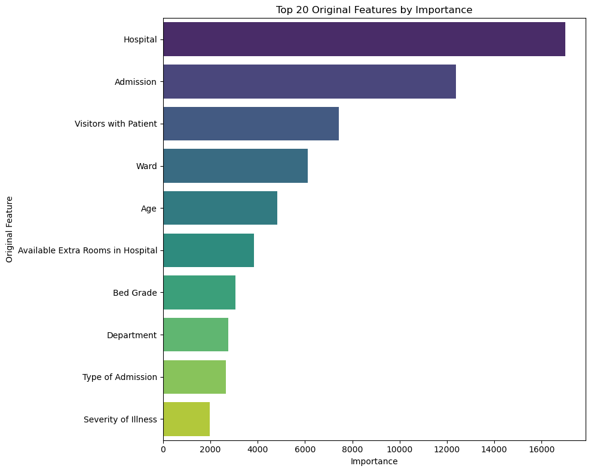

```python
# --- Step 1: Access the preprocessor ---
preprocessor = best_model.named_steps['preprocess']

# --- Step 2: Extract all transformed feature names and mappings ---
feature_names = []
original_feature_map = []
mapping_table = {}

for name, transformer, cols in preprocessor.transformers_:
    # Handle pipelines (like numeric_transformer, low_card_transformer, etc.)
    if hasattr(transformer, 'get_feature_names_out'):
        names = transformer.get_feature_names_out(cols)
    elif hasattr(transformer, 'named_steps'):
        # Access final step in the pipeline
        last_step = list(transformer.named_steps.values())[-1]
        if hasattr(last_step, 'get_feature_names_out'):
            names = last_step.get_feature_names_out(cols)
        else:
            names = cols  # No feature expansion (e.g., TargetEncoder)
    else:
        names = cols  # passthrough or simple transformer

    # Extend total feature list
    feature_names.extend(names)

    # Ensure all names are strings and replace numeric names with original column name
    names = [str(n) if isinstance(n, str) else c for n in names]

    # Build mapping: original column → list of encoded feature names
    for c in cols:
        mapped = [n for n in names if n.startswith(c + "_")] or [c]
        mapping_table[c] = mapped

    # Build original feature map for each encoded feature
    for n in names:
        base_col = n.split('_')[0] if '_' in n else n
        original_feature_map.append(base_col)

# --- Step 3: Extract feature importances ---
if 'clf' in best_model.named_steps:
    importances = best_model.named_steps['clf'].feature_importances_
elif 'ord' in best_model.named_steps:  # for OGBoost
    importances = best_model.named_steps['ord'].feature_importances_
else:
    raise ValueError("Unknown estimator in pipeline")

# --- Step 4: Create detailed feature importance DataFrame ---
fi_df = pd.DataFrame({
    'Encoded Feature': feature_names,
    'Original Feature': original_feature_map,
    'Importance': importances
}).sort_values('Importance', ascending=False)

# --- Step 5: Aggregate importances by original feature ---
grouped_fi = (
    fi_df.groupby('Original Feature')['Importance']
    .sum()
    .sort_values(ascending=False)
    .reset_index()
)

# --- Step 6: Print mapping table (for inspection) ---
print("🔍 Original → Encoded Feature Mapping:\n")
for orig, enc_list in mapping_table.items():
    print(f"{orig}: {enc_list}")

# --- Step 7: Plot top 20 features by importance ---
plt.figure(figsize=(10, 8))
sns.barplot(x='Importance', y='Original Feature', data=grouped_fi.head(20), palette="viridis")
plt.title("Top 20 Original Features by Importance")
plt.tight_layout()
plt.show()
```

## 7. Conclusion & Recommendations

These drivers make logical sense: patients with higher deposits or more visitors may correspond to different hospital types or care plans, and age naturally influences length of stay.

For future improvements, we recommend:

- Further hyperparameter tuning, for example by increasing cross-validation folds, exploring more parameter combinations, or use grid/Bayesian search for optimal settings.
- Feature engineering, for example by testing alternative imputation strategies, creating new derived features, or refining existing ones to enhance predictive power.